# Causes_RIOK_TRUE

2023-10-11

## Script to work on analyses for causes paper

##Taxonomic work is needed? # Morpho differentiation types: More CS sl than CS ss overall? # Need to find expectations and test against 50:50 mark

```
##
##  Pearson's Chi-squared test with Yates' continuity correction
##
## data:  cbind(expected, observed)
## X-squared = 10.575, df = 1, p-value = 0.001147
```

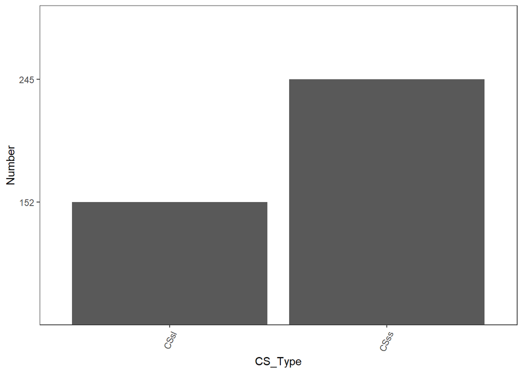

More CSss than the 50% benchmark (significant), so reject the idea that most CS are just due to taxonomic oversight.

# Available technology – More diagnostic differences in species described earlier?

```
##
##        FALSE TRUE
##   1750     4   14
##   1760     4    8
##   1770     1    7
##   1780     2    6
##   1790     1   11
##   1800     8    4
##   1810     7    6
##   1820    12    9
##   1830     8   15
##   1840     7   12
##   1850     5    7
##   1860    11   10
##   1870     6   11
##   1880     7    5
##   1890     3    2
##   1900     1   10
##   1910     2    3
##   1920     4    4
##   1930     5    5
##   1940     1    1
##   1950     1    3
##   1960     3    3
##   1970     3    5
##   1980     2    4
##   1990     5    6
##   2000     8   16
##   2010    12   13
```

```
##
##  Pearson's Chi-squared test
##
## data:  decademorpho$decade and decademorpho$CSss
## X-squared = 29.639, df = 26, p-value = 0.2828
```

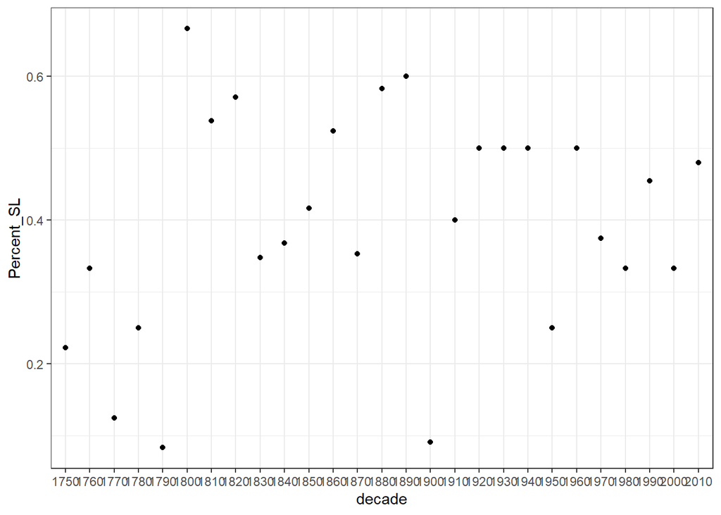

There is no trend in the percent of CSsl (diagnostic differences) through time; hypothesis not supported.

# Prevailing theories of nature and species origins - More CS in fragmented habitats in species described before Darwin?

```
##
##              1 10 100 1000 25  5
##   1756-1859  1 75  10   27 42 48
##   1860-1980  2 47  19   13 35 23
##   1981-2020  0 21  11    6 17 11
```

```
##
##  Pearson's Chi-squared test
##
## data:  breaks_HKK$decade_bin and breaks_HKK$HKK
## X-squared = 17.242, df = 10, p-value = 0.06917
```

```
##                      1        10        100       1000        25         5
## pre_Darwin 0.004926108 0.3694581 0.04926108 0.13300493 0.2068966 0.2364532
## pre_Kimura 0.014388489 0.3381295 0.13669065 0.09352518 0.2517986 0.1654676
## modern     0.000000000 0.3181818 0.16666667 0.09090909 0.2575758 0.1666667
```

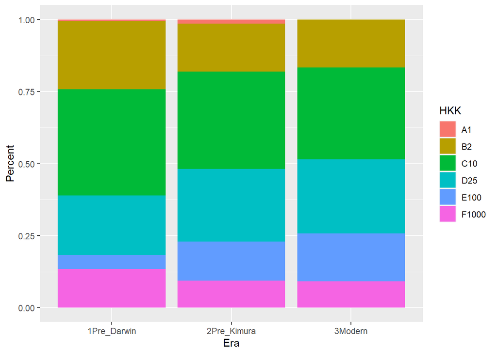

This is NOW ONLY MARGINALLY significant. HKK=10, = 1000 trends DOWN, HKK=25, =100 trend UP. HKK = 5 doesn’t trend but is largest before Darwin. So, it’s messy.

# Accessibility of habitat when species described - Percentage of CS in inaccessible habitats higher in earlier spp?

```
##
##        Difficult Easy Normal
##   1750         1    8     17
##   1760         0    3     11
##   1770         2    4      6
##   1780         1    2      7
##   1790         1    3     10
##   1800         0    4     12
##   1810         1    2     11
##   1820         2    8     20
##   1830         2   10     17
##   1840         2    6     24
##   1850         1    7     14
##   1860         1    8     22
##   1870         4    5     15
##   1880         4    1     12
##   1890         0    1      5
##   1900         1    1     11
##   1910         4    0      4
##   1920         2    1      8
##   1930         1    4      8
##   1940         0    1      3
##   1950         1    0      4
##   1960         0    2      6
##   1970         2    2      6
##   1980         3    1      4
##   1990         1    2      9
##   2000         7    6     15
##   2010         1    7     21
```

```
##
##  Pearson's Chi-squared test
##
## data:  decadeAccess$decade and decadeAccess$Access
## X-squared = 60.96, df = 52, p-value = 0.1848
```

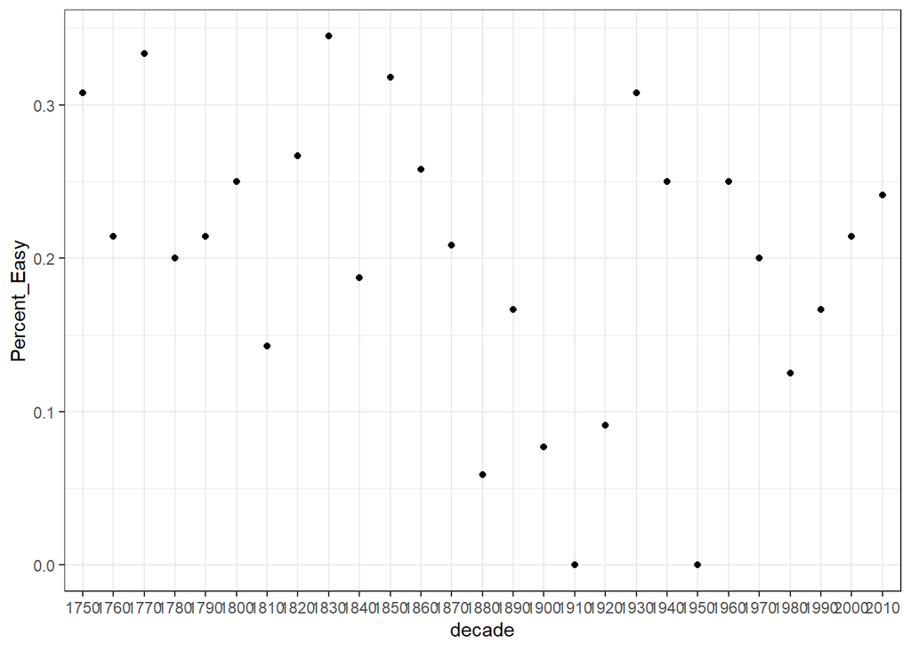

Hypothesis not supported. DIFFERENT FROM ALL SPECIES DATA.

## In sum, when we only look at species with CS (i.e. our database), the effect of taxonomic work goes away. This is interesting since that was the strongest effect in paper 1. THIS IS STILL TRUE WITH RIOK=TRUE.

## Effect of recent divergence - dispersal

# Larval type – Planktotrophic/pelagic larvae leads to less CS/NS)?

Note1: for this I’m working with a separate surveylarv input file where I have corrected larval types to pt, lt, dd, and removed all others, including cases where there are multiple types checked. (Most of those cases are where the two CS have different larvae.) This left 574 CS with larval info.

Note2: the data fail the homoscedasticity test (Bartlett’s) so I’ve used a nonparametric Kruskal-Wallis test to see if CS/NS is different among groups.

```
##       DD       LT       PT
## 3.659574 2.984615 2.969325
```

```
##       DD       LT       PT
## 2.678281 1.556160 1.970221
```

```
##
##  Kruskal-Wallis rank sum test
##
## data:  as.numeric(larv_NbCS$Nb_CS) and larv_NbCS$Larv_type
## Kruskal-Wallis chi-squared = 4.1431, df = 2, p-value = 0.126
```

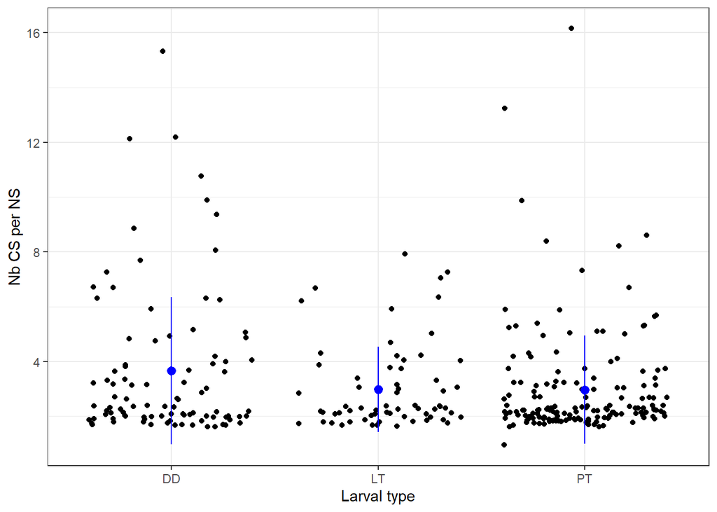

Hypothesis not supported. THIS IS DIFFERENT FROM USING ALL SPECIES.

# High HKK leads to more CS ss – testing this based on Nb_CS per HKK.

Note: data again failed homoscedasticity, using Kruskal Wallis test

```
##        1        5       10       25      100     1000
## 4.800000 3.231579 3.303797 2.934579 3.666667 3.157895
```

```
##        1        5       10       25      100     1000
## 3.701351 2.100925 2.339658 1.844272 1.954017 2.161262
```

```
##
##  Kruskal-Wallis rank sum test
##
## data:  HKK_NbCS$Nb_CS and HKK_NbCS$HKKv3
## Kruskal-Wallis chi-squared = 10.544, df = 5, p-value = 0.06122
```

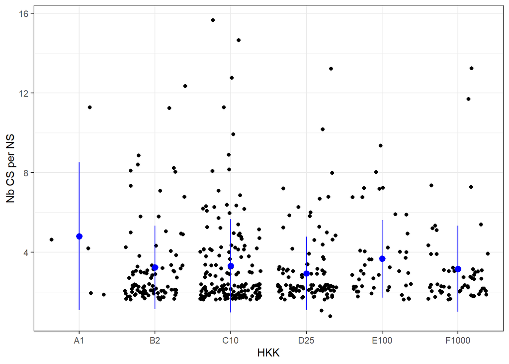

Result: This is VERY different from the whole species dataset - marginally signficant. However, the difference is OPPOSITE from what was expected = higher NBCS in low HKK bins. Maybe compare pairwise in the future?

## In sum, NO support for the role of recent divergence as measured by a proxy of dispersal when considering only RIOK=TRUE cases.

# More stable environments = more CSss or statistical differences

Note: stable = pelagic, deepsea, cave, coralreef; not stable = coastal, intertidal, estuarine, seagrass

```
##
##         FALSE TRUE
##   FALSE   103   49
##   TRUE    138  107
```

```
##
##  Pearson's Chi-squared test with Yates' continuity correction
##
## data:  stable_hab$CSss and stable_hab$Stable
## X-squared = 4.6752, df = 1, p-value = 0.0306
```

```
##                FALSE      TRUE
## CSss_total 0.5726141 0.6858974
## CSsl_total 0.4273859 0.3141026
```

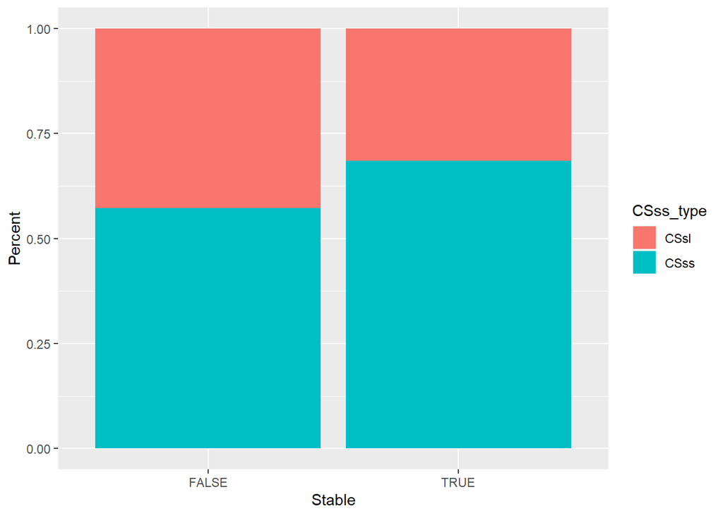

Result: More CSss found in stable environments. Hypothesis supported. Stronger support with RIOK=TRUE.

# Note also that stabilizing selection predicts more CSss than CSsl, which is what we find (see above).

## In sum, we generally have support for this idea.

## High Ne (neutral hypotheses)

# Reproductive investment - Low reproductive investment leads to more statistical divergence? (Repro. investment proxy for Ne)

Note1: Again this uses the surveylarv dataset with hand cleaning. Note2: Planktotrophic = LOW; Lecithotrophic, Brooding, DD = HIGH; If a spp could be both low and high, have marked it NA (is usually bc the CS have different larval types). Anything else got marked NA to be conservative. Note3: Only 248 cases are considered here, meaning that is where we have morphological data AND larval type data AND RIOK = TRUE

```
##
##                      HIGH LOW
##   Diagnostic           47  49
##   No differentiation   17  20
##   Statistic            55  60
```

```
##
##  Pearson's Chi-squared test
##
## data:  surveylarv$Morpho_diff and surveylarv$Repro_invest
## X-squared = 0.099237, df = 2, p-value = 0.9516
```

Result: not significant.

# High HKK leads to more CS ss (HKK as proxy for Ne)

```
##
##                       1  5 10 25 100 1000
##   Diagnostic          4 33 46 45   8    7
##   No differentiation  0  6 17 12  14    5
##   Statistic           0 35 55 33  13   32
```

```
##            1          5        10        25       100      1000
## stat_total 0 0.47297297 0.4661017 0.3666667 0.3714286 0.7272727
## diag_total 1 0.44594595 0.3898305 0.5000000 0.2285714 0.1590909
## nod_total  0 0.08108108 0.1440678 0.1333333 0.4000000 0.1136364
```

```
##
##    1    5   10   25  100 1000
##    4   74  118   90   35   44
```

```
##
##  Pearson's Chi-squared test
##
## data:  surveymorpho$Morpho_diff and surveymorpho$HKKv3
## X-squared = 44.837, df = 10, p-value = 2.327e-06
```

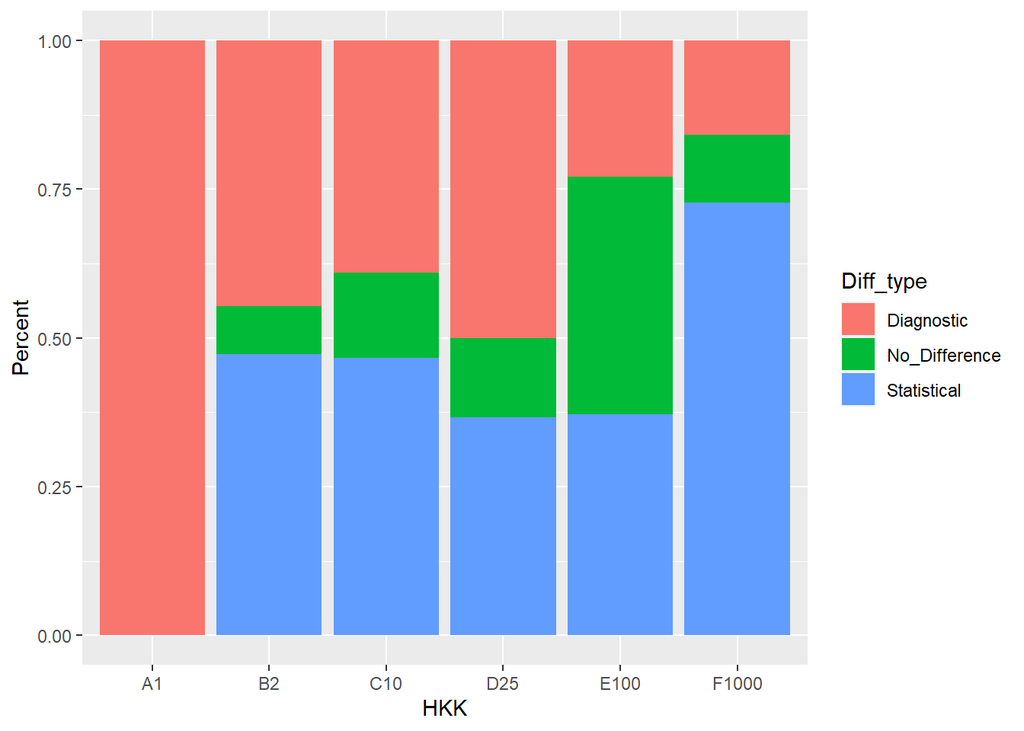

```
##
##        FALSE TRUE
##   1        4    0
##   5       33   41
##   10      46   72
##   25      45   45
##   100      8   27
##   1000     7   37
```

```
##
##  Pearson's Chi-squared test
##
## data:  surveymorpho$HKKv3 and surveymorpho$CSss
## X-squared = 25.456, df = 5, p-value = 0.0001137
```

```
##            1         5        10  25       100      1000
## CSss_total 0 0.5540541 0.6101695 0.5 0.7714286 0.8409091
## CSsl_total 1 0.4459459 0.3898305 0.5 0.2285714 0.1590909
```

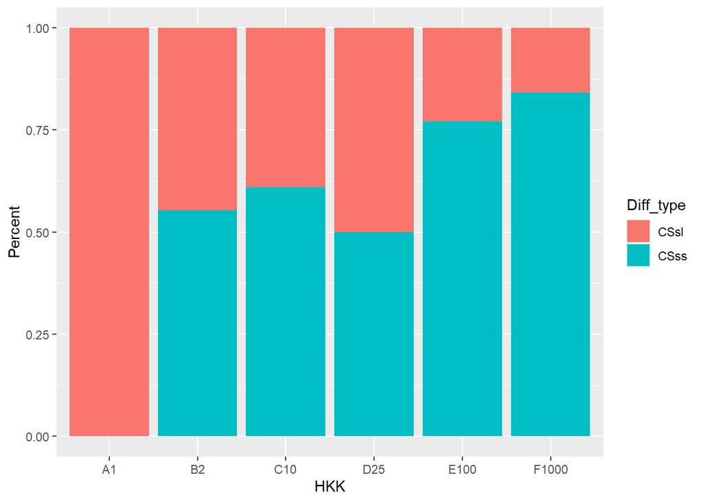

Results: More diagnostic differences (=CSsl) at lower HKK values, both when considering 3 morpho classes AND just ss vs sl

## In sum, we see support for the neutral hypothesis if we use HKK as a proxy for Ne but NOT if we use reproductive investment.

## Hypothesis: effect of recent divergence – More sympatric than allopatric CS/NS for a given Nsg?

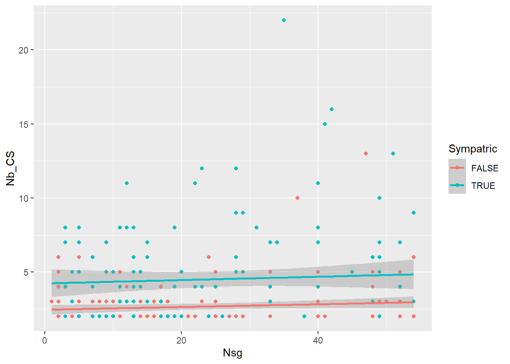

```
## ANOVA Table (type II tests)
##
##      Effect DFn DFd     F     p p<.05      ges
## 1     Nb_CS   1 324 1.844 0.175       0.006000
## 2 Sympatric   1 324 0.254 0.615       0.000784
```

These results aren’t statistically significant (ANCOVA) but the graph is in line with the hypothesis. Marginal support.

## Selection against hybrids – More diagnostic differences in sympatry than allopatry?

```
##
##         FALSE TRUE
##   FALSE    68   36
##   TRUE     81   82
```

```
##
##  Pearson's Chi-squared test with Yates' continuity correction
##
## data:  surveymorpho$CSss and surveymorpho$Sympatric
## X-squared = 5.7182, df = 1, p-value = 0.01679
```

```
##                FALSE      TRUE
## CSss_total 0.5436242 0.6949153
## CSsl_total 0.4563758 0.3050847
```

[figure not shown]

## Importance of biological traits

# More diagnostic traits with hard skeleton?

```
##
##                        N   Y
##   Diagnostic          33 112
##   No differentiation  16  42
##   Statistic           40 129
```

```
##
##  Pearson's Chi-squared test
##
## data:  surveymorpho$Morpho_diff and surveymorpho$hard_skeleton
## X-squared = 0.54164, df = 2, p-value = 0.7628
```

```
##                    N         Y
## stat_total 0.4494382 0.4558304
## diag_total 0.3707865 0.3957597
## nod_total  0.1797753 0.1484099
```

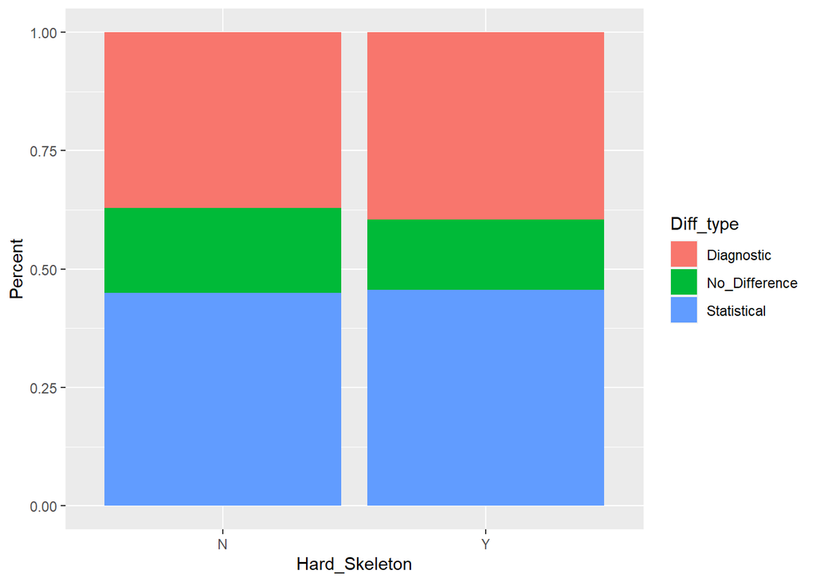

THIS IS NO LONGER SUPPORTED, AND REALLY DRAMATICALLY SO, WHEN RIOK=TRUE. This must mean that species that were dropped in some way affected this. Investigate!

# More diagnostic traits with image vision?

```
##
##                       N  Y
##   Diagnostic         64 81
##   No differentiation 33 25
##   Statistic          82 87
```

```
##
##  Pearson's Chi-squared test
##
## data:  surveymorpho$Morpho_diff and surveymorpho$image
## X-squared = 2.7215, df = 2, p-value = 0.2565
```

Result: hypothesis not supported

# More diagnostic traits with internal fertilization?

```
##
##                       B  E  I
##   Diagnostic         50 53 42
##   No differentiation 22 29  7
##   Statistic          37 86 46
```

```
##
##  Pearson's Chi-squared test
##
## data:  surveymorpho$Morpho_diff and surveymorpho$ferti
## X-squared = 14.85, df = 4, p-value = 0.005023
```

```
##                    B         E          I
## stat_total 0.3394495 0.5119048 0.48421053
## diag_total 0.4587156 0.3154762 0.44210526
## nod_total  0.2018349 0.1726190 0.07368421
```

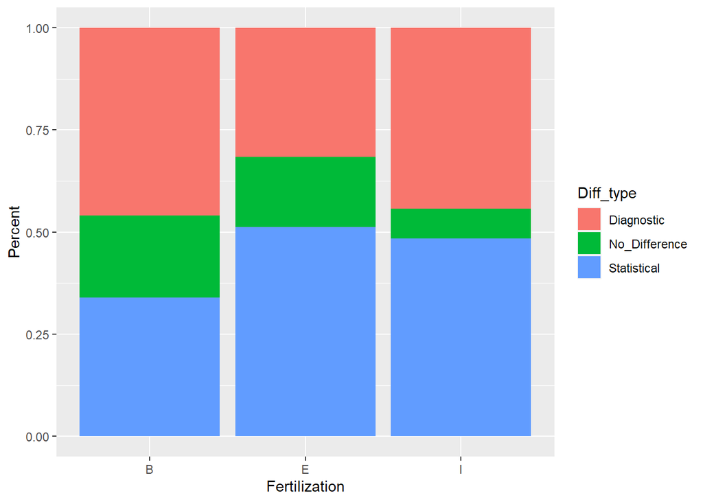

Result: hypothesis supported. Species with internal fert are more likely to have diag diffs, ie CSsl. This is also true if I remove the “both” category. Hypothesis accepted.

# More diagnostic traits with external genitalia?

```
##
##                        B   N   Y
##   Diagnostic          30  75  40
##   No differentiation  17  35   6
##   Statistic           16 111  42
```

```
##
##  Pearson's Chi-squared test
##
## data:  surveymorpho$Morpho_diff and surveymorpho$genitals
## X-squared = 19.979, df = 4, p-value = 0.0005042
```

```
##                    B         N          Y
## stat_total 0.2539683 0.5022624 0.47727273
## diag_total 0.4761905 0.3393665 0.45454545
## nod_total  0.2698413 0.1583710 0.06818182
```

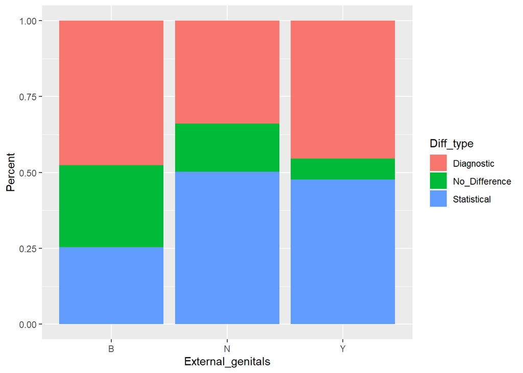

Result: more diagnostic traits with external, hypothesis accepted. This is also true if only considering CSss and CSsl (though p = 0.052, so marginal), AND when gastropods are removed (the only class with “both”).

## In sum, fertilization and genitalia still have a role in determining the TYPE of CS that is found (ss vs sl) BUT the role of hard skeletons went away? Need to look into this.

## So, overall conclusions: When looking at the full dataset, there is support for several (but not all) sets of hypotheses. Interestingly, the effect of taxonomic work/effort seems to go away, while the effect of taxonomic class remains. Some support for both selection-based and neutral ideas. Slightly less support for biological factors here - both skeletons and larval types flipped significance dramatically when only considering RIOK.